# 🧘 Analisi Esplorativa dei Dati (EDA) — App di Yoga

### Progetto Finale · Master Data Analysis · Start2impact

**Contesto.** Lavoriamo per un'app che promuove la pratica **inclusiva** dello yoga: istruttori qualificati pubblicano ogni giorno nuove classi (dal rilassamento al dinamico) e gli utenti possono partecipare a **challenge** a tema (4–12 settimane) guadagnando punti.

**Obiettivo dell'EDA.** Esplorare il dataset e ottenere una panoramica del comportamento degli utenti, mettendo a fuoco tre domande guida del progetto:

1. **Esistono gruppi (cluster) di utenti** con comportamenti e interessi diversi?
2. **Gli utenti stanno crescendo?**
3. **Cosa contribuisce di più al successo del prodotto**, per pianificare il prossimo anno?

Questa EDA prepara il terreno per le fasi successive (clustering → personas → dashboard Tableau → proposta strategica).

## 1. Setup e caricamento dei dati

```python
import pandas as pd
import numpy as np
import matplotlib.pyplot as plt
import matplotlib.ticker as mticker
import seaborn as sns
import warnings
warnings.filterwarnings("ignore")

# --- Stile grafico coerente (palette "yoga": salvia, terracotta, blu polvere, sabbia) ---
PALETTE = ["#6B8E7F", "#C17767", "#7B9EA8", "#D4B896", "#9A8CB5", "#B0785C"]
INK = "#3D4A42"
sns.set_theme(style="whitegrid")
plt.rcParams.update({
    "figure.dpi": 110,
    "font.size": 11,
    "axes.titlesize": 13,
    "axes.titleweight": "bold",
    "axes.titlecolor": INK,
    "axes.labelcolor": INK,
    "axes.edgecolor": "#CBD2CC",
    "text.color": INK,
    "xtick.color": INK,
    "ytick.color": INK,
    "axes.grid": True,
    "grid.color": "#E8ECE9",
    "figure.facecolor": "white",
    "axes.facecolor": "white",
})
sns.set_palette(PALETTE)

df = pd.read_csv("dataset.csv")
print(f"Dataset caricato: {df.shape[0]} righe × {df.shape[1]} colonne")
df.head()
```

```
Dataset caricato: 999 righe × 12 colonne
```

|  | class_date | user_uuid | category | coach_id | language | level | challenge_id | country | subscription_date | platform | class_id | stars |
| --- | --- | --- | --- | --- | --- | --- | --- | --- | --- | --- | --- | --- |
| 0 | 1-2-2023 | 2 | meditation | 102 | it | basic | 3 | it | 6-1-2022 | tv | 2157 | 1 |
| 1 | 22-5-2023 | 241 | power yoga | 111 | it | basic | 1 | it | 11-5-2022 | pc | 6172 | 3 |
| 2 | 6-8-2022 | 173 | power yoga | 117 | it | advanced | 3 | it | 12-12-2021 | pc | 6255 | 2 |
| 3 | 8-8-2023 | 217 | hatha | 100 | en | intermediate | 3 | uk | 7-2-2022 | tv | 3317 | 4 |
| 4 | 11-3-2022 | 230 | power yoga | 113 | fr | basic | 2 | fr | 9-1-2020 | pc | 6159 | 1 |

## 2. Struttura e qualità dei dati

Prima di analizzare, verifichiamo che i dati siano affidabili: tipi, valori mancanti, duplicati, coerenza temporale. In un progetto reale questo passo evita conclusioni sbagliate.

```python
print("=== Tipi di dato ===")
print(df.dtypes, "\n")
print("=== Valori mancanti per colonna ===")
print(df.isnull().sum(), "\n")
print(f"Righe duplicate (identiche): {df.duplicated().sum()}")
print("\n=== Valori unici per colonna ===")
for c in df.columns:
    print(f"  {c:<18}: {df[c].nunique():>4} unici")
```

```
=== Tipi di dato ===
class_date             str
user_uuid            int64
category               str
coach_id             int64
language               str
level                  str
challenge_id         int64
country                str
subscription_date      str
platform               str
class_id             int64
stars                int64
dtype: object

=== Valori mancanti per colonna ===
class_date           0
user_uuid            0
category             0
coach_id             0
language             0
level                0
challenge_id         0
country              0
subscription_date    0
platform             0
class_id             0
stars                0
dtype: int64

Righe duplicate (identiche): 0

=== Valori unici per colonna ===
  class_date        :  554 unici
  user_uuid         :  240 unici
  category          :    4 unici
  coach_id          :   23 unici
  language          :    3 unici
  level             :    3 unici
  challenge_id      :    4 unici
  country           :    3 unici
  subscription_date :  219 unici
  platform          :    3 unici
  class_id          :  636 unici
  stars             :    5 unici
```

```python
# Conversione delle date e controllo di coerenza temporale
df["class_date"] = pd.to_datetime(df["class_date"], format="%d-%m-%Y")
df["subscription_date"] = pd.to_datetime(df["subscription_date"], format="%d-%m-%Y")

print("Intervallo pratiche (class_date):     ",
      df["class_date"].min().date(), "→", df["class_date"].max().date())
print("Intervallo iscrizioni (subscription): ",
      df["subscription_date"].min().date(), "→", df["subscription_date"].max().date())

# Nessuna pratica dovrebbe avvenire PRIMA dell'iscrizione
incoerenti = (df["class_date"] < df["subscription_date"]).sum()
print(f"\nPratiche registrate PRIMA dell'iscrizione (impossibili): {incoerenti}")
```

```
Intervallo pratiche (class_date):      2021-01-08 → 2023-12-28
Intervallo iscrizioni (subscription):  2020-01-02 → 2022-12-23

Pratiche registrate PRIMA dell'iscrizione (impossibili): 0
```

> ✅ **Qualità dei dati.** Nessun valore mancante, nessun duplicato, nessuna incoerenza temporale. Il dataset è pulito e internamente coerente: possiamo fidarci delle analisi.

```python
# ⚠️ Controllo ridondanza: 'language' e 'country' sembrano descrivere la stessa cosa?
print("Tabella incrociata language × country:\n")
print(pd.crosstab(df["language"], df["country"]))
```

```
Tabella incrociata language × country:

country    fr   it   uk
language
en          0    0  312
fr        222    0    0
it          0  465    0
```

> ⚠️ **Finding di data modeling — `language` ≡ `country`.** La tabella incrociata mostra una corrispondenza **perfetta 1:1** (`it`↔`it`, `en`↔`uk`, `fr`↔`fr`): ogni utente ha lingua e paese perfettamente allineati. Le due colonne sono **ridondanti** e portano la stessa informazione. Nelle analisi useremo un'unica dimensione geografica/linguistica per non "contare due volte" lo stesso segnale.

## 3. Analisi univariata — com'è fatta la nostra base

Guardiamo la distribuzione delle variabili categoriche principali: **categoria di yoga, livello di difficoltà, piattaforma, lingua/paese**. Ci dice chi sono gli utenti e cosa consumano.

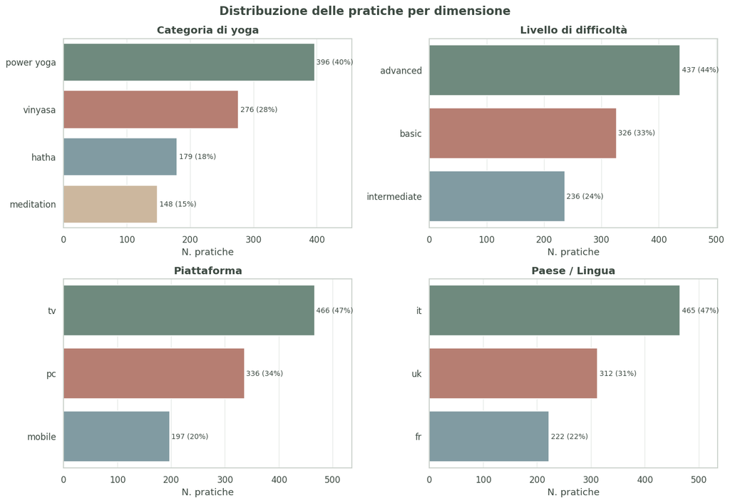

```python
fig, axes = plt.subplots(2, 2, figsize=(13, 9))
mapping = [
    ("category", "Categoria di yoga"),
    ("level",    "Livello di difficoltà"),
    ("platform", "Piattaforma"),
    ("country",  "Paese / Lingua"),
]
for ax, (col, title) in zip(axes.ravel(), mapping):
    vc = df[col].value_counts()
    sns.barplot(x=vc.values, y=vc.index, ax=ax, palette=PALETTE)
    ax.set_title(title)
    ax.set_xlabel("N. pratiche")
    ax.set_ylabel("")
    for i, v in enumerate(vc.values):
        ax.text(v + 3, i, f"{v} ({v/len(df)*100:.0f}%)", va="center", fontsize=9, color=INK)
    ax.margins(x=0.15)
plt.suptitle("Distribuzione delle pratiche per dimensione", fontsize=15, fontweight="bold", color=INK)
plt.tight_layout()
plt.show()
```

**Lettura.**

- **Power yoga** è la categoria più consumata (≈40% delle pratiche), seguita da vinyasa; hatha e meditation sono di nicchia — utile per il palinsesto dei contenuti.
- Prevalgono le pratiche di livello **advanced**: la base attiva tende ad essere allenata.
- La **TV** è la piattaforma più usata, poi PC; il mobile è minoritario (leva di crescita?).
- Il mercato **italiano** è il più grande (≈47%), poi UK e Francia.

### 3.1 La variabile `stars`: un segnale utile o rumore?

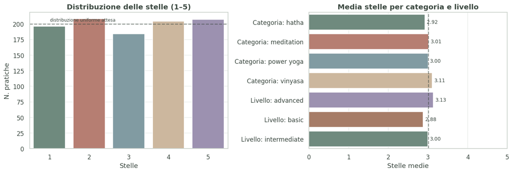

```
Media stelle globale: 3.02

Media stelle con vs senza challenge:
has_ch
False    2.98
True     3.03
Name: stars, dtype: float64
```

```python
fig, axes = plt.subplots(1, 2, figsize=(13, 4.5))

# Distribuzione delle stelle
vc = df["stars"].value_counts().sort_index()
sns.barplot(x=vc.index, y=vc.values, ax=axes[0], palette=PALETTE)
axes[0].set_title("Distribuzione delle stelle (1–5)")
axes[0].set_xlabel("Stelle"); axes[0].set_ylabel("N. pratiche")
axes[0].axhline(len(df)/5, ls="--", color=INK, alpha=.6)
axes[0].text(0.02, len(df)/5+4, "distribuzione uniforme attesa", fontsize=8, color=INK)

# Media stelle per diversi tagli
cuts = {
    "Categoria": df.groupby("category")["stars"].mean(),
    "Livello":   df.groupby("level")["stars"].mean(),
}
rows = []
for label, s in cuts.items():
    for k, v in s.items():
        rows.append((f"{label}: {k}", v))
lab = [r[0] for r in rows]; val = [r[1] for r in rows]
sns.barplot(x=val, y=lab, ax=axes[1], palette=PALETTE)
axes[1].set_title("Media stelle per categoria e livello")
axes[1].set_xlabel("Stelle medie"); axes[1].set_xlim(0, 5)
axes[1].axvline(df["stars"].mean(), ls="--", color=INK, alpha=.6)
for i, v in enumerate(val):
    axes[1].text(v+0.05, i, f"{v:.2f}", va="center", fontsize=9, color=INK)
plt.tight_layout(); plt.show()

print("Media stelle globale:", round(df['stars'].mean(), 2))
print("\nMedia stelle con vs senza challenge:")
print(df.assign(has_ch=df['challenge_id']>0).groupby('has_ch')['stars'].mean().round(2))
```

> ⚠️ **Finding — `stars` non ha potere discriminante.** La distribuzione è sostanzialmente **uniforme** (ogni voto 1–5 pesa ~20%) e la **media resta ~3.0 in ogni taglio** — categoria, livello, con/senza challenge. Non correla con nessuna dimensione di prodotto. Trattiamo quindi `stars` come **rumore** e **non** ci costruiamo sopra decisioni strategiche. Dichiararlo è una scelta di rigore: riconoscere che una variabile non informa è parte dell'analisi, non un limite.

## 4. Analisi temporale — gli utenti stanno crescendo?

Questa è la domanda centrale. La affrontiamo su due piani distinti: **attività** (pratiche completate nel tempo) e **acquisizione** (nuove iscrizioni nel tempo).

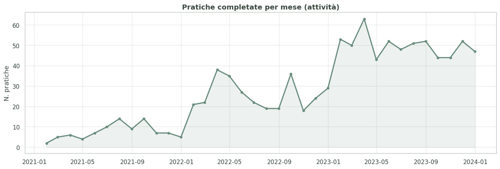

```
Pratiche completate per anno:
class_date
2021     90
2022    310
2023    599
dtype: int64
```

```python
# Attività: pratiche per mese
prat_mese = df.set_index("class_date").resample("ME").size()

fig, ax = plt.subplots(figsize=(13, 4.5))
ax.plot(prat_mese.index, prat_mese.values, color=PALETTE[0], lw=2.2, marker="o", ms=4)
ax.fill_between(prat_mese.index, prat_mese.values, color=PALETTE[0], alpha=0.12)
ax.set_title("Pratiche completate per mese (attività)")
ax.set_ylabel("N. pratiche"); ax.set_xlabel("")
plt.tight_layout(); plt.show()

print("Pratiche completate per anno:")
print(df.groupby(df["class_date"].dt.year).size())
```

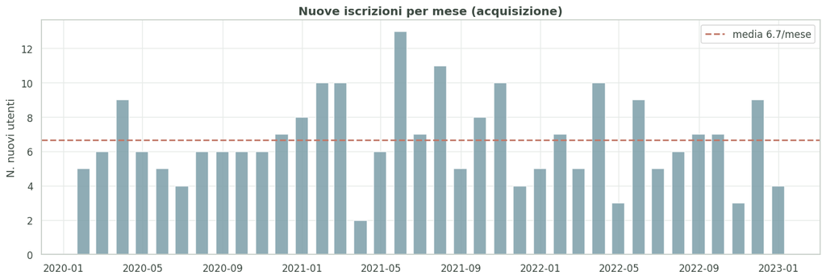

```python
# Acquisizione: nuove iscrizioni per mese (un utente conta una volta sola)
primi = df.drop_duplicates("user_uuid")
iscr_mese = primi.set_index("subscription_date").resample("ME").size()

fig, ax = plt.subplots(figsize=(13, 4.5))
ax.bar(iscr_mese.index, iscr_mese.values, width=20, color=PALETTE[2], alpha=0.85)
ax.axhline(iscr_mese.mean(), ls="--", color=PALETTE[1], lw=1.8,
           label=f"media {iscr_mese.mean():.1f}/mese")
ax.set_title("Nuove iscrizioni per mese (acquisizione)")
ax.set_ylabel("N. nuovi utenti"); ax.set_xlabel(""); ax.legend()
plt.tight_layout(); plt.show()
```

> Significato: l'app cresce perché la base **esistente pratica sempre di più** (retention + frequenza), non perché ne entrano molti nuovi. È un'ottima notizia sul valore del prodotto — e indica che la leva #1 per il prossimo anno è **massimizzare l'engagement** (challenge) più che il solo acquisto.

## 5. Comportamento degli utenti

Passiamo dal livello "pratica" al livello "utente": quante pratiche fa ciascuno, per quanto tempo resta attivo, quanto è "profondo" il rapporto con l'app.

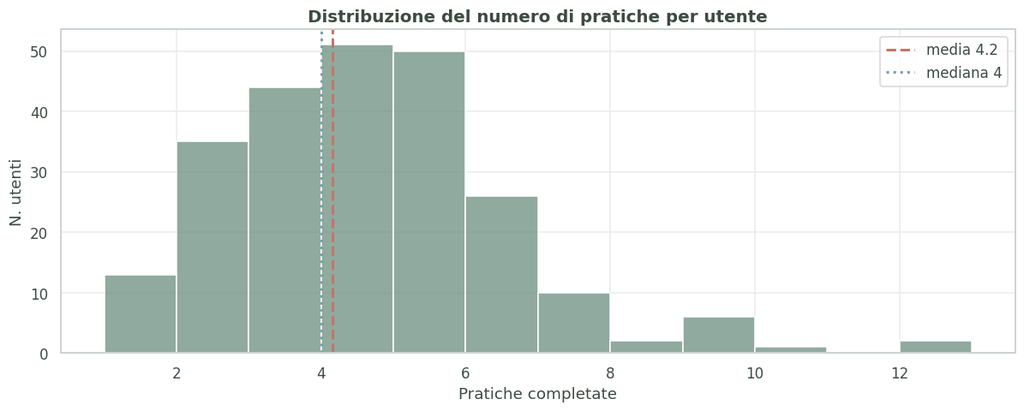

```
count    240.00
mean       4.16
std        1.92
min        1.00
25%        3.00
50%        4.00
75%        5.00
max       12.00
dtype: float64

Utenti con 1 sola pratica (one-and-done): 13 (5.4%)
Utenti 'power user' (≥8 pratiche):        11 (4.6%)
```

```python
ppu = df.groupby("user_uuid").size()

fig, ax = plt.subplots(figsize=(11, 4.5))
sns.histplot(ppu, bins=range(1, ppu.max()+2), color=PALETTE[0], edgecolor="white", ax=ax)
ax.axvline(ppu.mean(), ls="--", color=PALETTE[1], lw=2, label=f"media {ppu.mean():.1f}")
ax.axvline(ppu.median(), ls=":", color=PALETTE[2], lw=2, label=f"mediana {ppu.median():.0f}")
ax.set_title("Distribuzione del numero di pratiche per utente")
ax.set_xlabel("Pratiche completate"); ax.set_ylabel("N. utenti"); ax.legend()
plt.tight_layout(); plt.show()

print(ppu.describe().round(2))
print(f"\nUtenti con 1 sola pratica (one-and-done): {(ppu==1).sum()} "
      f"({(ppu==1).mean()*100:.1f}%)")
print(f"Utenti 'power user' (≥8 pratiche):        {(ppu>=8).sum()} "
      f"({(ppu>=8).mean()*100:.1f}%)")
```

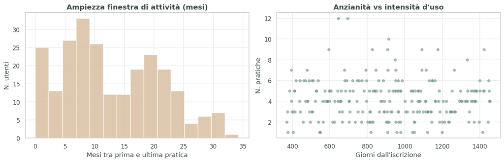

```python
# Anzianità (tenure) e finestra di attività per utente
agg = df.groupby("user_uuid").agg(
    prima_pratica=("class_date", "min"),
    ultima_pratica=("class_date", "max"),
    iscrizione=("subscription_date", "first"),
    n_pratiche=("class_id", "size"),
)
agg["mesi_attivita"] = ((agg["ultima_pratica"] - agg["prima_pratica"]).dt.days / 30.44).round(1)
agg["giorni_iscritto"] = (df["class_date"].max() - agg["iscrizione"]).dt.days

fig, axes = plt.subplots(1, 2, figsize=(13, 4.3))
sns.histplot(agg["mesi_attivita"], bins=15, color=PALETTE[3], edgecolor="white", ax=axes[0])
axes[0].set_title("Ampiezza finestra di attività (mesi)")
axes[0].set_xlabel("Mesi tra prima e ultima pratica"); axes[0].set_ylabel("N. utenti")

sns.scatterplot(data=agg, x="giorni_iscritto", y="n_pratiche",
                color=PALETTE[0], alpha=0.6, ax=axes[1])
axes[1].set_title("Anzianità vs intensità d'uso")
axes[1].set_xlabel("Giorni dall'iscrizione"); axes[1].set_ylabel("N. pratiche")
plt.tight_layout(); plt.show()
```

**Lettura.**

- In media **~4 pratiche per utente** (mediana 4, max 12): rapporto ancora giovane per la maggioranza, con una coda di utenti molto affezionati.
- C'è una minoranza di **one-and-done** (1 sola pratica) da recuperare con l'onboarding, e un nucleo di **power user** su cui costruire community/advocacy.
- La finestra di attività è ampia per molti utenti: chi rimane, rimane a lungo — coerente con la storia "crescita da engagement".

## 6. Le challenge come motore dell'engagement

L'app punta sulle challenge (4–12 settimane, a punti). Quanto pesano davvero sull'attività? Nota: assumiamo `challenge_id = 0` = **pratica libera** (fuori da ogni challenge); `1/2/3` = challenge attive.

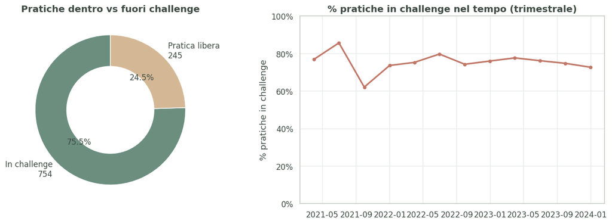

```
Quota di pratiche svolte dentro una challenge: 75.5%
```

```python
df["in_challenge"] = df["challenge_id"] > 0
quota = df["in_challenge"].mean() * 100

fig, axes = plt.subplots(1, 2, figsize=(13, 4.5))

# Torta partecipazione
sizes = [df["in_challenge"].sum(), (~df["in_challenge"]).sum()]
axes[0].pie(sizes, labels=[f"In challenge\n{sizes[0]}", f"Pratica libera\n{sizes[1]}"],
            autopct="%1.1f%%", colors=[PALETTE[0], PALETTE[3]],
            wedgeprops=dict(width=0.42, edgecolor="white"), startangle=90)
axes[0].set_title("Pratiche dentro vs fuori challenge")

# Quota challenge nel tempo
ts = df.set_index("class_date").resample("QE")["in_challenge"].mean() * 100
axes[1].plot(ts.index, ts.values, color=PALETTE[1], lw=2.2, marker="o", ms=4)
axes[1].set_title("% pratiche in challenge nel tempo (trimestrale)")
axes[1].set_ylabel("% pratiche in challenge"); axes[1].set_ylim(0, 100)
axes[1].yaxis.set_major_formatter(mticker.PercentFormatter(decimals=0))
plt.tight_layout(); plt.show()

print(f"Quota di pratiche svolte dentro una challenge: {quota:.1f}%")
```

> 🎯 **Finding — le challenge sono il motore.** Circa il **75%** di tutte le pratiche avviene **dentro una challenge**. È di gran lunga il comportamento dominante e il candidato naturale come **leva strategica #1**: se le pratiche in challenge sono la maggioranza, potenziare numero, varietà e "aggancio" delle challenge è la via più diretta per far crescere l'attività.

## 7. Categorie e coach nel tempo

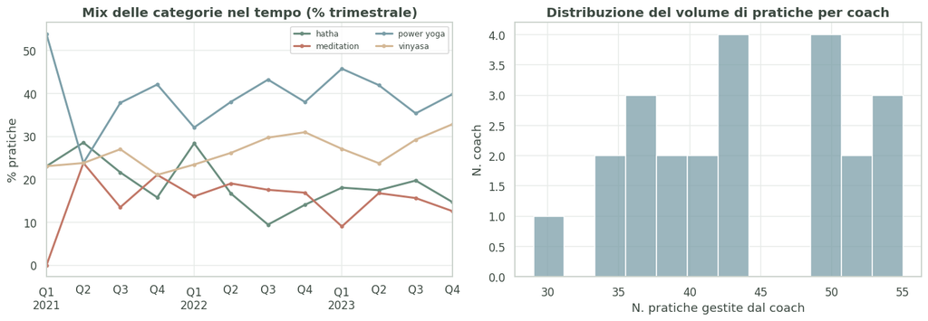

```
Coach attivi: 23 | media pratiche/coach: 43.4 (min 29, max 55)
```

```python
# Andamento delle categorie nel tempo (quota trimestrale)
piv = (df.assign(q=df["class_date"].dt.to_period("Q").dt.to_timestamp())
         .groupby(["q", "category"]).size().unstack(fill_value=0))
piv_pct = piv.div(piv.sum(axis=1), axis=0) * 100

fig, axes = plt.subplots(1, 2, figsize=(13, 4.6))
piv_pct.plot(ax=axes[0], color=PALETTE, lw=2, marker="o", ms=3)
axes[0].set_title("Mix delle categorie nel tempo (% trimestrale)")
axes[0].set_ylabel("% pratiche"); axes[0].set_xlabel("")
axes[0].legend(title="", fontsize=8, ncol=2)

# Volume per coach
cc = df["coach_id"].value_counts()
sns.histplot(cc.values, bins=12, color=PALETTE[2], edgecolor="white", ax=axes[1])
axes[1].set_title("Distribuzione del volume di pratiche per coach")
axes[1].set_xlabel("N. pratiche gestite dal coach"); axes[1].set_ylabel("N. coach")
plt.tight_layout(); plt.show()

print(f"Coach attivi: {df['coach_id'].nunique()} | "
      f"media pratiche/coach: {cc.mean():.1f} (min {cc.min()}, max {cc.max()})")
```

## 8. Aggregazione a livello utente — ponte verso il clustering

Per la fase successiva (segmentazione → personas) serve una tabella **una riga per utente** con feature comportamentali. La costruiamo qui come output dell'EDA.

```python
def moda(s):
    return s.mode().iloc[0] if not s.mode().empty else np.nan

user = df.groupby("user_uuid").agg(
    n_pratiche      = ("class_id", "size"),
    categoria_top   = ("category", moda),
    livello_top     = ("level", moda),
    piattaforma_top = ("platform", moda),
    paese           = ("country", moda),
    quota_challenge = ("in_challenge", "mean"),
    n_coach_diversi = ("coach_id", "nunique"),
    iscrizione      = ("subscription_date", "first"),
    prima_pratica   = ("class_date", "min"),
    ultima_pratica  = ("class_date", "max"),
)
user["mesi_attivita"]  = ((user["ultima_pratica"] - user["prima_pratica"]).dt.days/30.44).round(1)
user["giorni_iscritto"] = (df["class_date"].max() - user["iscrizione"]).dt.days
user["quota_challenge"] = (user["quota_challenge"]*100).round(0)

print(f"Tabella utente pronta: {user.shape[0]} utenti × {user.shape[1]} feature\n")
user.head(8)
```

```
Tabella utente pronta: 240 utenti × 12 feature
```

| user_uuid | n_pratiche | categoria_top | livello_top | piattaforma_top | paese | quota_challenge | n_coach_diversi | iscrizione | prima_pratica | ultima_pratica | mesi_attivita | giorni_iscritto |
| --- | --- | --- | --- | --- | --- | --- | --- | --- | --- | --- | --- | --- |
| 1 | 7 | power yoga | basic | tv | it | 71.0 | 6 | 2021-05-20 | 2022-05-13 | 2023-11-18 | 18.2 | 952 |
| 2 | 6 | power yoga | advanced | tv | it | 83.0 | 4 | 2022-01-06 | 2023-01-10 | 2023-07-05 | 5.8 | 721 |
| 3 | 3 | hatha | advanced | mobile | it | 67.0 | 3 | 2020-07-22 | 2021-01-12 | 2021-07-16 | 6.1 | 1254 |
| 4 | 4 | hatha | advanced | pc | fr | 100.0 | 3 | 2022-05-10 | 2023-01-25 | 2023-07-10 | 5.5 | 597 |
| 5 | 4 | power yoga | advanced | tv | uk | 25.0 | 3 | 2022-01-25 | 2023-03-14 | 2023-12-26 | 9.4 | 702 |
| 6 | 2 | hatha | advanced | tv | it | 100.0 | 2 | 2020-09-14 | 2022-03-05 | 2022-09-01 | 5.9 | 1200 |
| 7 | 5 | power yoga | basic | mobile | fr | 60.0 | 4 | 2021-09-01 | 2022-02-22 | 2022-12-24 | 10.0 | 848 |
| 8 | 2 | meditation | advanced | tv | fr | 100.0 | 2 | 2022-04-23 | 2023-10-27 | 2023-12-05 | 1.3 | 614 |

```python
# Esportiamo gli output per le fasi successive (clustering + estratti Tableau)
user.to_csv("utenti_features.csv")
df.to_csv("pratiche_pulite.csv", index=False)
print("Salvati: utenti_features.csv (livello utente) e pratiche_pulite.csv (livello pratica)")
print("\nStatistiche delle feature numeriche a livello utente:")
user[["n_pratiche","quota_challenge","n_coach_diversi","mesi_attivita","giorni_iscritto"]].describe().round(1)
```

```
Salvati: utenti_features.csv (livello utente) e pratiche_pulite.csv (livello pratica)

Statistiche delle feature numeriche a livello utente:
```

|  | n_pratiche | quota_challenge | n_coach_diversi | mesi_attivita | giorni_iscritto |
| --- | --- | --- | --- | --- | --- |
| count | 240.0 | 240.0 | 240.0 | 240.0 | 240.0 |
| mean | 4.2 | 75.2 | 3.7 | 13.0 | 914.2 |
| std | 1.9 | 23.5 | 1.7 | 8.4 | 302.9 |
| min | 1.0 | 0.0 | 1.0 | 0.0 | 370.0 |
| 25% | 3.0 | 60.0 | 2.8 | 6.4 | 660.2 |
| 50% | 4.0 | 75.0 | 4.0 | 11.1 | 916.0 |
| 75% | 5.0 | 100.0 | 5.0 | 19.9 | 1147.0 |
| max | 12.0 | 100.0 | 10.0 | 34.3 | 1456.0 |

## 9. Sintesi degli insight

| # | Insight | Evidenza | Implicazione |
| --- | --- | --- | --- |
| 1 | **La crescita è trainata dall'engagement, non dall'acquisizione** | Pratiche 90→310→599 per anno; iscrizioni piatte (~6/mese) | La leva del prossimo anno è la **frequenza d'uso**, non solo l'acquisto |
| 2 | **Le challenge sono il motore** | ~75% delle pratiche avviene dentro una challenge | Potenziare numero/varietà/aggancio delle **challenge** = crescita più diretta |
| 3 | **Power yoga + livello advanced dominano** | ~40% power yoga; prevalenza advanced | Palinsesto e onboarding vanno **bilanciati** verso principianti/nicchie |
| 4 | **Nucleo fedele + coda one-and-done** | Media ~4 pratiche/utente; c'è chi resta a lungo e chi molla subito | Investire su **onboarding** (recupero) e **community** (power user) |
| 5 | **`language` ≡ `country`** | Corrispondenza 1:1 perfetta | Usare **una sola** dimensione geografica per non duplicare il segnale |
| 6 | **`stars` è rumore** | Distribuzione uniforme, media ~3.0 ovunque | **Escludere** le stelle dalle decisioni strategiche |

**Prossimi passi.**

1. **Clustering** (K-means) sulla tabella `utenti_features.csv` → identificare i gruppi di utenti.
2. **Personas** costruite dai cluster (non inventate).
3. **Dashboard Tableau** dagli estratti puliti (`pratiche_pulite.csv`).
4. **Proposta strategica** ancorata ai 6 insight qui sopra.

*EDA realizzata in Python (pandas, matplotlib, seaborn) — Progetto Finale Start2impact.*